# PSTAT 231 HW1

E3:

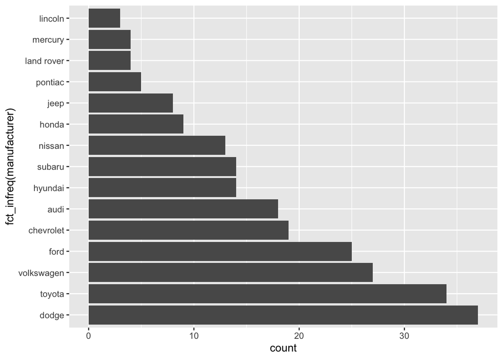

```r
# Basic barplot
library(forcats)
p<-ggplot(data=mpg, aes(x=fct_infreq(manufacturer))) +
  geom_bar()
# Horizontal bar plot
p + coord_flip()
```

Dodge prduced the most cars and Lincoln produced the least.

E4:

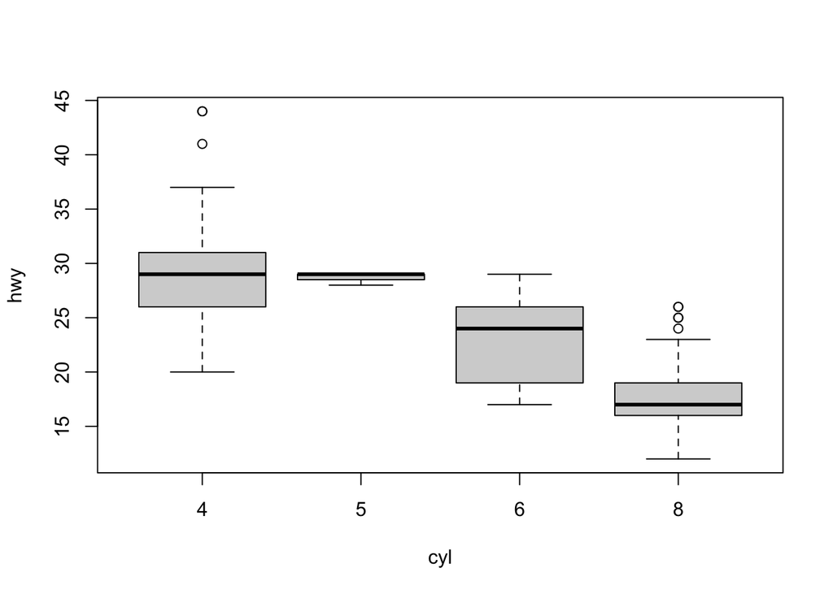

```r
boxplot(hwy~cyl, data=mpg)
```

The higher the cylinder, the lower mpg on highway for a vehicle.

E5:

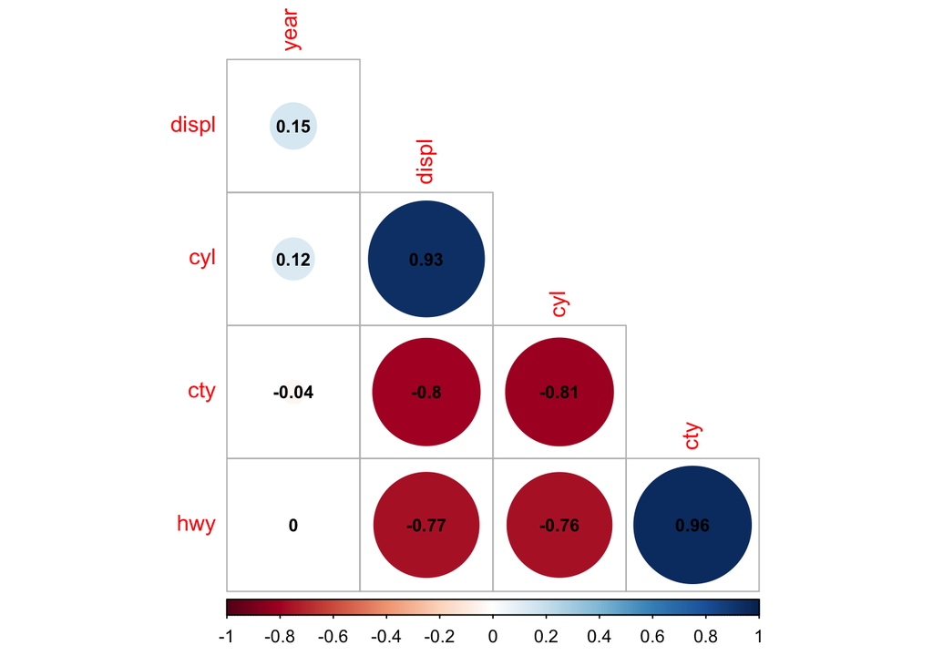

```r
library(corrplot)
library(dplyr)

M <- select_if(mpg, is.numeric)

## leave blank on non-significant coefficient
## add significant correlation coefficients
corrplot(cor(M), method = 'circle', type = 'lower', insig='blank',
         addCoef.col ='black', number.cex = 0.8, order = 'AOE', diag=FALSE)
```

The pairs cyl/disply, cty/cyl,cty/displ, hwy/displ, hwy/cyl, and hwy/cty all hold significant correlations. Cyl/displ and hwy/cty hold psitive correlations, while the rest are negative. The positive correlations make sense. A vehicle’s city/highway performance generally improve together, and their differences are only slightly better/worse. If a vehicle has more cylinders, It will carry more volume and hence, higher displacement. I would have assumed city and highway performance would improve with more cylinders/displacement. Those variables generally improve a vehicle performance but now looking back, it also chugs more gas.

E6:

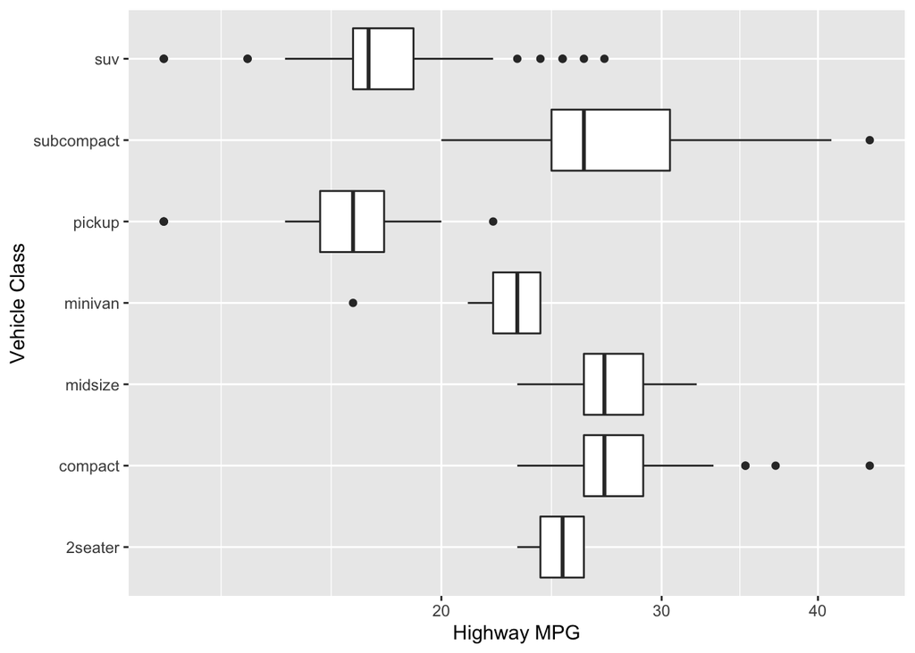

```r
library(ggthemes)
  ggplot(data=mpg, aes(x=class, y=hwy)) +
  geom_boxplot()+
  coord_flip()+
  scale_y_log10()+
  labs(x="Vehicle Class", y="Highway MPG") +  scale_color_gdocs()#+ theme_stata(scheme = "s1mono")
```

E7:

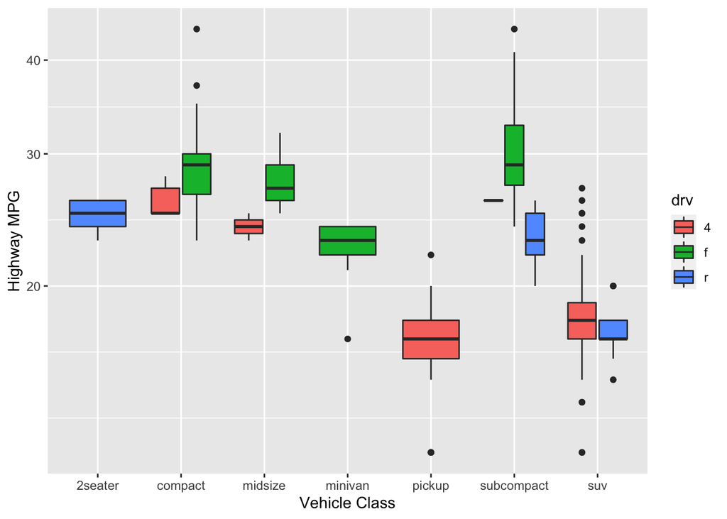

```r
ggplot(data=mpg, aes(x=factor(class), y=hwy, fill = drv)) +
geom_boxplot()+
scale_y_log10()+
labs(x="Vehicle Class", y="Highway MPG") + scale_colour_stata(scheme = "s2color")
```

E8:

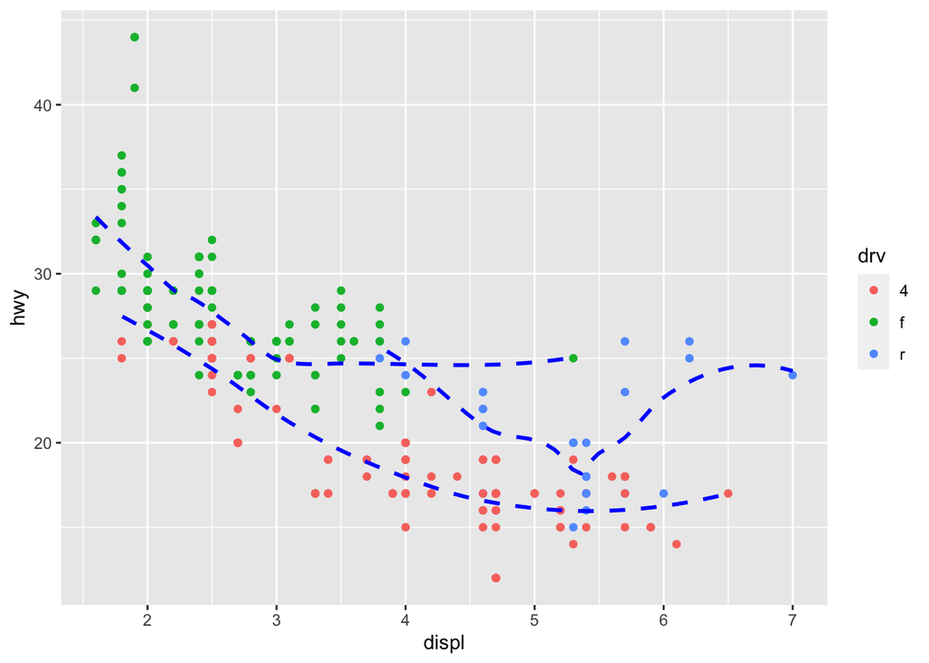

```r
ggplot(mpg, aes(x=displ, y=hwy, color=drv)) +
  geom_point() +
  geom_smooth(aes(group=drv), method=loess, se=FALSE, fullrange=TRUE, linetype='dashed', color='blue')
```